# Summative 1 - Data Science Boot Camp: Windmill Pictures - Automated Subtitling Market Segmentation

-

2025-03-17

**Introduction**

As laid out in Summative 2 my team’s project was to introduce automated subtitling to Windmill Pictures new Windmill@Home service.

My particular task was to provide any required Data Analysis / Science related tasks.The core product I delivered was the Market Score Index which helps us understand what countries may be appropriate for automated subtitling.

I think my most significant contributions to the group project were:

1. **Leadership & Organisation**: I led the group to agree daily meetings to review progress so far. I also agreed that we would use Github for storage of data & code. I also set up a Whatsapp Group that enabled us to coordinate well across the week.
2. **Data Science support**: I created all data visualisations for the group including an interactive Shiny Dashboard. In addition I used K Means Clustering to help us identify countries that may be appropriate markets for our automated translation services. I also used linear regression as an approach to assess the quality of the English Proficiency Index (EPI)<sup>5</sup> including appropriate interpretation of the p-values and r<sup>2</sup>.
3. **Requirements Gathering**: I led the group to lay out what our basic requirements were and laid them out clearly as shown in the Formative assessment for this project.
4. **Collaboration & Co-operation**: I worked well with other members of the group particularly my Data Engineer colleague. Our tasks involved significant integration and use of Github’s facilities to ensure that our code worked together.
5. **Exploring Resources**: I used the resources we had available effectively selecting technologies and using the Northeastern University library system to access the Ethnologue Database. I also worked to assign tasks across the group to ensure that we were all working towards a coherent end goal.

In the rest of this notebook you can find the data cleaning, reporting, plots and analysis I performed throughout this project. At the end you can find a link to a live shiny dashboard and links to the additional code that powers this.

The github repository for this work can be found here: https://github.com/NHS-Ryan/windmill_mov_subtitles

**Data Import & Cleaning**

Before completing the analysis below we had to create the initial Country Information file which gave us the information we needed to assess what markets would be appropriate for automated subtitling.

We agreed requirements for the Country Information file as a group and my Data Engineer colleague and myself divided the work between us to find the required sources. In the end we sourced the median income & average GDP growth from the World Bank<sup>1</sup>,<sup>2</sup> & information relating to the most commonly spoken language in each country, number of native English speakers & second language English speakers per country from the Ethnologue Database<sup>3</sup>.

Note that we initially considered using the EPI<sup>5</sup> as a source for the fraction of people in a given country that were proficient in English. However I found in the methodology section of the index that participants used for the EPI were not randomly selected and instead it was a convenience sample of people enrolled in particpating English language schools across the world. Initially we were struggling to find any source for these data so we did some analysis to understand whether the EPI was a source worth working with. We had a good quality data source for European countries: specifically the Eurobarometer Poll ‘Europeans & Their Languages’<sup>6</sup>. This poll had a large sample of participants across the EU and was appropriately randomised. Given this I assumed it was a higher quality source for the data we needed. I extracted the EU countries from the EPI & joined this with the Eurobarometer data for matching countries. I performed a linear regression on this data which had a statistically significant correlation, but only a r<sup>2</sup> of 0.17. Given this low correlation we felt that this was not an appropriate data source and instead pursued other avenues which ended with us finding and using the Ethnologue Database.

In addition to the core Country Information file that we constructed from the above sources I am also using data that tells us what countries Netflix is restricted in<sup>4</sup>. This helps us filter out markets that Windmill Pictures will not be able to launch Windmill@Home in.

Finally we use a Supported Languages file that shows which languages that Windmill Pictures already translates into (English, Spanish, Italian, German, French & Portuguese). We will use this to remove countries where their most commonly spoken language is already supported by Windmill Pictures and therefore do not require our proposed automated subtitling solution.

This code joins the Netflix Restricted Countries & Supported Languages file to our main Country Information table. We also do some basic tidying by combining the English L1 (native speakers) & English L2 (second language speakers) into a single Total English Speakers column.

```r
supported_languages$supported_language_flag = 0
netflix_restricted_countries$netflix_restricted_countries_flag = 0

country_information <- left_join(country_information, supported_languages,
                                 by = c("primary_language" = "supported_languages")
                                 )

country_information <- left_join(country_information, netflix_restricted_countries,
                                 by = c("country" = "netflix_restricted_countries")
                                 )

# Disable scientific notation for values
options(scipen = 999)

# Replace "NULL" strings with 0 in english_speakers_l1 & convert to numeric
country_information$english_speakers_l1[country_information$english_speakers_l1 == "NULL"] <- 0
country_information$english_speakers_l1 <- as.numeric(country_information$english_speakers_l1)

# Replace "NULL" strings with 0 in english_speakers_l2 & convert to numeric
country_information$english_speakers_l2[country_information$english_speakers_l2 == "NULL"] <- 0
country_information$english_speakers_l2 <- as.numeric(country_information$english_speakers_l2)

# Create English Speakers total as a sum of l1 + l2 columns
country_information$english_speakers_total <-
  country_information$english_speakers_l1 + country_information$english_speakers_l2

country_information$supported_language_flag <- country_information$supported_language_flag %>%
  replace_na(1)

country_information$netflix_restricted_countries_flag <- country_information$netflix_restricted_countries_flag %>%
  replace_na(1)

country_information
```

```
## # A tibble: 123 × 11
##    country     population english_speakers_l1 english_speakers_l2 median_income
##    <chr>            <dbl>               <dbl>               <dbl>         <dbl>
##  1 Afghanistan   42647492                 500             2300000          341.
##  2 Albania        2791765                   0                9000         5263.
##  3 Algeria       46814308                7260             2520000         2810.
##  4 Argentina     45696159              100000             7000000         9092.
##  5 Armenia        2973840                   0              144000         3791.
##  6 Australia     26713205            18300000                   0        45711.
##  7 Austria        9120813               14700             6500000        43282.
##  8 Azerbaijan    10336577                   0                2800         3965.
##  9 Bahamas         401283                   0               37300        24896.
## 10 Bangladesh   173562364                   0            29800000         2567.
## # ℹ 113 more rows
## # ℹ 6 more variables: avg_gdp_change_5_years <dbl>, primary_language <chr>,
## #   primary_language_speakers <dbl>, supported_language_flag <dbl>,
## #   netflix_restricted_countries_flag <dbl>, english_speakers_total <dbl>
```

Create a Treemap of languages including an ‘unsupported_languages’ category to demonstrate how much of the overall global market we are missing.

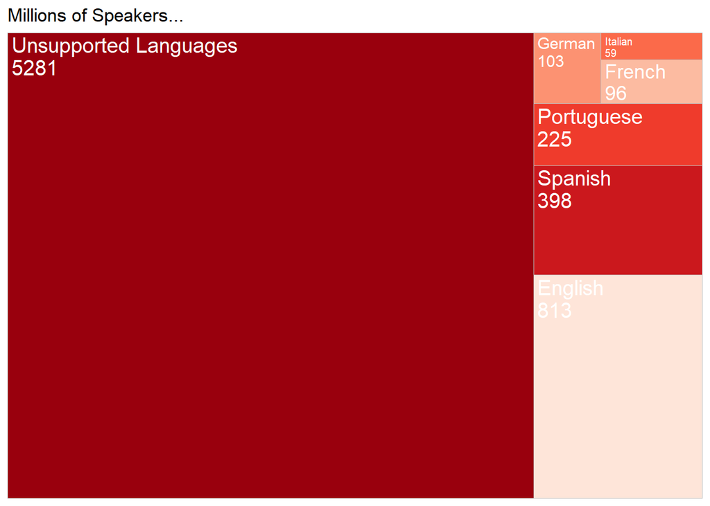

```r
temp_df <- data.frame(primary_language = character(),
                      total_value = numeric())

unsupported_val = (country_information %>%
         filter(supported_language_flag == 1) %>%
         summarize(total_value = sum(population)))$total_value[1]

temp_df <- temp_df %>% add_row(
  primary_language = "Unsupported Languages",
  total_value = unsupported_val)

country_information %>%
  select(country,population,
         primary_language,supported_language_flag) %>%
  filter(supported_language_flag == 0) %>%
  group_by(primary_language) %>%
  summarise(total_value = sum(population, na.rm = TRUE)) %>%
  add_row(temp_df) %>%
  mutate(primary_language = str_to_title(primary_language)) %>%
  group_by(primary_language) %>%
  summarise(total_value = (total_value = sum(round(total_value / 1000000,0)))) %>%
  arrange(desc(total_value)) %>%
  ggplot(aes(area = total_value, fill = primary_language,
               label = paste(primary_language, total_value,
                             sep = "\n"))) +
    geom_treemap() +
    geom_treemap_text(colour = "white",
                      place = "topleft",
                      size = 15) +
    theme(legend.position = "none") +
    scale_fill_brewer(palette = "Reds") +
    labs(title = "Millions of Speakers...")
```

**Target Population**

We are now going to add a Target Population column.This column gives us the population of a country that speaks the most commonly spoken language in that country minus any English Speakers. This gives us an understanding of how many people in that country are at least potentially interested in automated subtitling of English Language movies in the Windmill Pictures catalogue.

**Caveats for our target_population calculation:** Simply deducting English speakers from the primary_language_speakers value overestimates the number of English speakers that should be removed: for example in India Ethnologue estimates that there are ~268 million English speakers. Obviously not all of these people Hindi as their first language therefore just deducting English speakers from the primary_language_speakers reduces the size of the market in an unrealistic way. The level of detail required to account for this problem is not available on Ethnologue (or possibly anywhere) so we have had to make do with the calculation laid out above.

```r
country_information$target_population <-
  round(country_information$supported_language_flag *
  ((country_information$population * country_information$primary_language_speakers) -
     country_information$english_speakers_total),0)


# Remove countries with a target population less than a million as these markets are not the right place to start for our service.
country_information <- country_information %>%
  filter(target_population > 1000000)
```

**Market Score**

The Market Score is intended to help us understand which markets are best for us to target with our automated subtitling.

```r
# Simple function to normalise datasets from 0 to 1.
normalise <- function(x) {
  return((x - min(x, na.rm = TRUE)) / (max(x, na.rm = TRUE) - min(x, na.rm = TRUE)))
}

country_information$median_income_score <-
  normalise(country_information$median_income) * 3.5

country_information$avg_gdp_change_5_years_score <-
  normalise(country_information$avg_gdp_change_5_years) * 1.5

country_information$target_population_score <-
  normalise(country_information$target_population) * 5

country_information$market_score <-
  (country_information$median_income_score +
     country_information$avg_gdp_change_5_years_score +
     country_information$target_population_score) *
  country_information$supported_language_flag
```

**Market Clustering**

As an alternate to the Market Score I am also using K Means Clustering approach using the same variables as were used for the Market Score: target population, median income, 5 year average GDP growth.

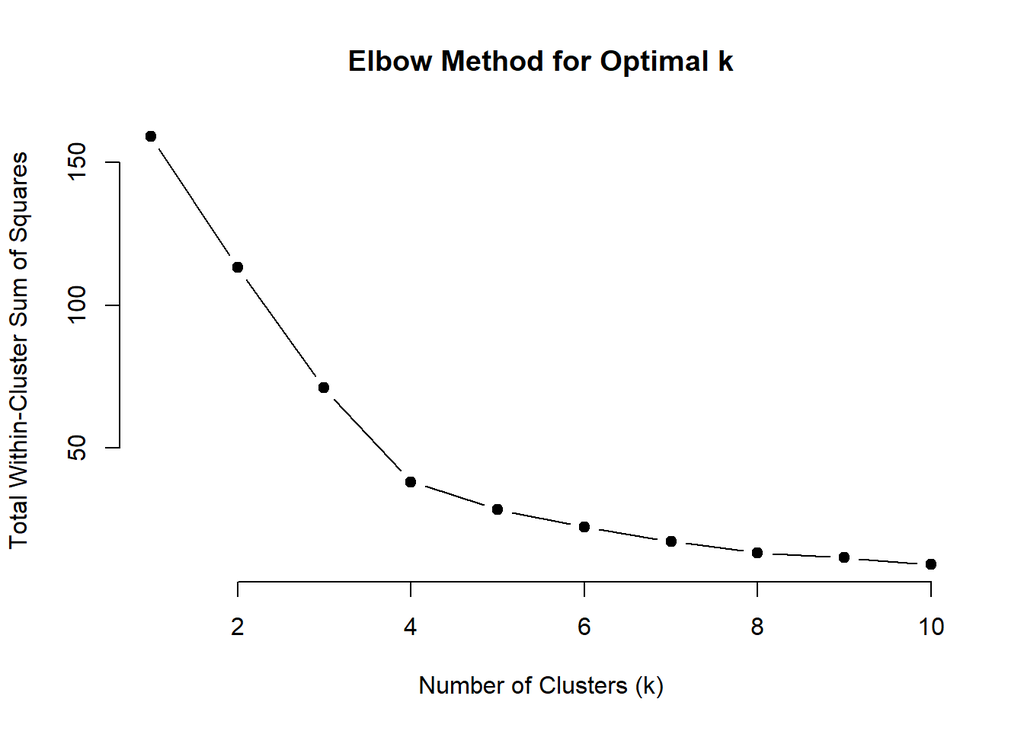

```r
# Select relevant columns & apply scaling
data <- country_information[, c("median_income", "avg_gdp_change_5_years", "target_population")]
scaled_data <- scale(data)

# Determine the optimal number of clusters using the Elbow Method
set.seed(123)  # For reproducibility
wss <- sapply(1:10, function(k) kmeans(scaled_data, centers = k, nstart = 10)$tot.withinss)

# Plot the Elbow Method graph
plot(1:10, wss, type = "b", pch = 19, frame = FALSE,
     xlab = "Number of Clusters (k)", ylab = "Total Within-Cluster Sum of Squares",
     main = "Elbow Method for Optimal k")
```

```r
# Perform K-Means clustering with an optimal k (adjusted to 4 based on elbow plot results)
k <- 4  # Choose based on elbow method
kmeans_result <- kmeans(scaled_data, centers = k, nstart = 25)

# Add cluster labels to the original dataset
country_information$cluster <- as.factor(kmeans_result$cluster)
```

**Cluster Visualisations & Summaries**

Here we can see scatter plots showing the relationships between median income and our other two variables: 5 year average GDP change & target population.

These scatter plots help us understand how the clusters were formed by the K Means algorithm and how to interpret them effectively.

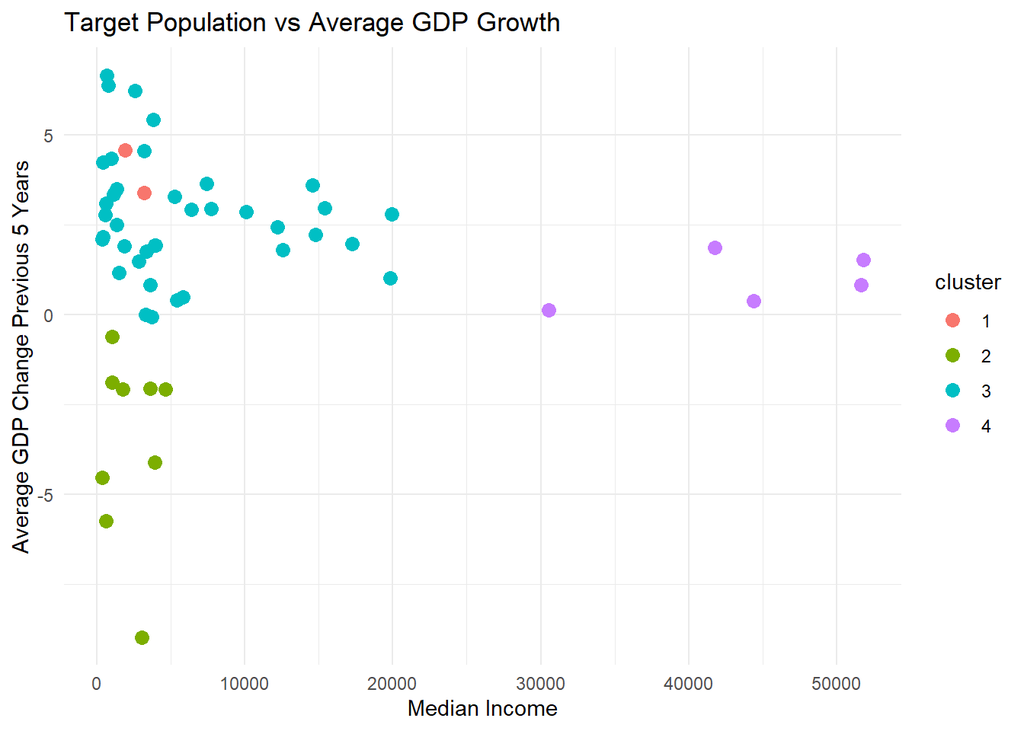

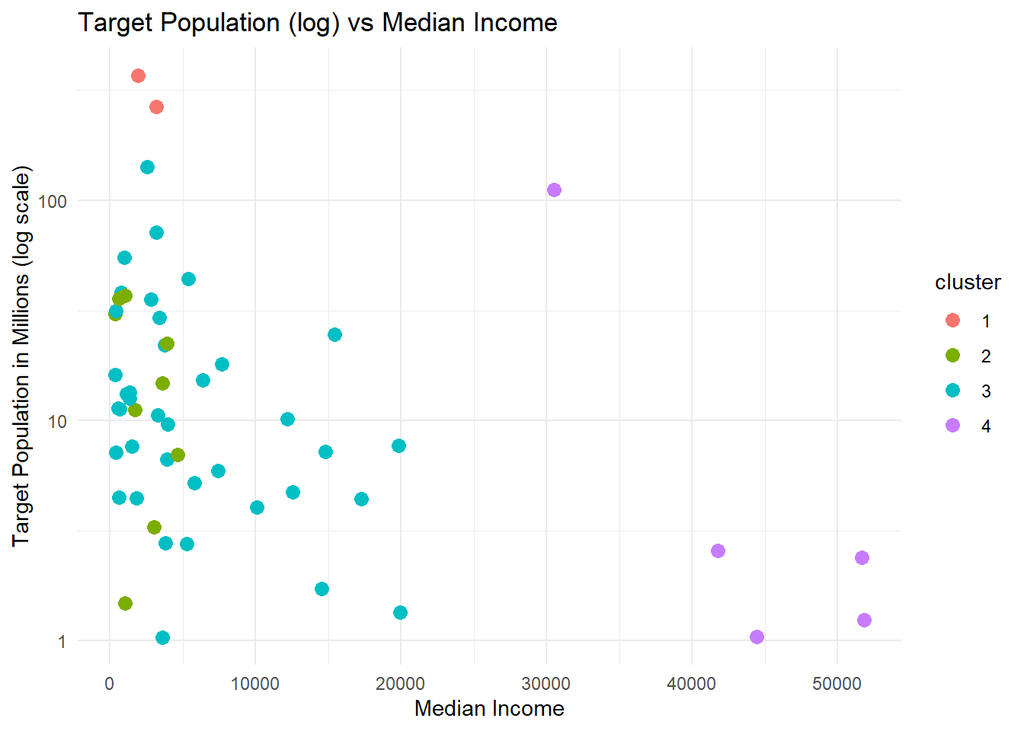

To help us grasp these clusters more effectively I have given them names:

Cluster 1 - The big & getting bigger Cluster 2 - The small & getting smaller Cluster 3 - The varied middle Cluster 4 - The overlooked rich

Interactive tables with each cluster with names and descriptions highlighting their key characteristics plus pros and cons to help us understand which markets to target.

# Cluster 1 - The big & getting bigger

|  | Country | Target Population (millions) | Average GDP Change (5 Years) | Median Income |
| --- | --- | --- | --- | --- |
| 1 | India | 370.2 | 4.6 | 1907 |
| 2 | Indonesia | 266.4 | 3.4 | 3189 |

The Big & Getting Bigger cluster is defined by having only 2 countries that both have massive populations: India & Indonesia. India's population is smaller than you would expect as we are only focusing on the Hindi speaking population. Both countries have low incomes, but with very strong growth.  
Pros: large population of middle class consumers even when we account for the low median income. In addition because of these country's strong growth we should expect them to add millions of consumers each year that are now able to afford streaming services.  
Cons: low median income

# Cluster 2 - The Small & Getting Smaller

|  | Country | Target Population (millions) | Average GDP Change (5 Years) | Median Income |
| --- | --- | --- | --- | --- |
| 1 | Myanmar | 37 | -1.9 | 1050 |
| 2 | Sudan | 35.8 | -5.7 | 598 |
| 3 | Afghanistan | 30.5 | -4.5 | 341 |
| 4 | Ukraine | 22.4 | -4.1 | 3919 |
| 5 | Sri Lanka | 14.8 | -2.1 | 3612 |
| 6 | Haiti | 11.2 | -2.1 | 1736 |
| 7 | Libya | 7 | -2.1 | 4639 |
| 8 | Lebanon | 3.3 | -9 | 3027 |
| 9 | Lesotho | 1.5 | -0.6 | 1037 |

The Small & Getting Smaller cluster is defined by having shrinking incomes.  
Pros: Some countries have large populations.  
Cons: Generally low incomes and in all cases those incomes are shrinking. Many of these countries are defined by internal or international conflict.

# Cluster 3 - The Varied Middle

|  | Country | Target Population (millions) | Average GDP Change (5 Years) | Median Income |
| --- | --- | --- | --- | --- |
| 1 | Bangladesh | 142 | 6.2 | 2567 |
| 2 | Egypt | 71.9 | 4.5 | 3185 |
| 3 | Tanzania | 55 | 4.3 | 972 |
| 4 | Thailand | 44.1 | 0.4 | 5393 |
| 5 | Ethiopia | 38 | 6.4 | 787 |
| 6 | Algeria | 35.4 | 1.5 | 2810 |
| 7 | Madagascar | 31.6 | 2.2 | 421 |
| 8 | Morocco | 29.3 | 1.8 | 3373 |
| 9 | Poland | 24.5 | 3 | 15411 |
| 10 | Iraq | 22 | -0.1 | 3732 |

[output cut: 28 more lines]

The Varied Middle Cluster is difficult to easily define, it features countries with large populations and low incomes (e.g. Pakistan) and small populations with high incomes (e.g. Lithuania). Overall this segment is too varied to treat as a sensible group. A separate piece of analysis on this group individually is probably the best approach if we look at this group in particular.  
Pros: very varied with several opportunities buried within the group. In particular if we were to treat all the Arabic speaking countries as a single market they would likely be grouped with the Big & Getting Bigger cluster..  
Cons: too diverse to treat as a single unit and to approach with a single strategy.

# Cluster 4 - The Overlooked Rich

|  | Country | Target Population (millions) | Average GDP Change (5 Years) | Median Income |
| --- | --- | --- | --- | --- |
| 1 | Japan | 111.5 | 0.1 | 30520 |
| 2 | Belgium | 2.6 | 1.9 | 41743 |
| 3 | Qatar | 2.4 | 0.8 | 51677 |
| 4 | Sweden | 1.2 | 1.5 | 51831 |
| 5 | Finland | 1 | 0.4 | 44416 |

The Overlooked Rich cluster is defined by countries that have high median incomes, but do not speak one of our core translation languages (English, Portuguese, Spanish, German, Italian). Japan makes up 94% of the population of this cluster.  
Pros: High incomes with reasonable GDP growth and already well established media markets.  
Cons: Other than Japan this cluster is made up of very small population countries.

**Market Score Tables**

Overall summary table:

|  | country | primary_language | market_score |
| --- | --- | --- | --- |
| 1 | India | Hindi | 6.4 |
| 2 | Indonesia | Indonesian | 5 |
| 3 | Sweden | Swedish | 4.5 |
| 4 | Japan | Japanese | 4.4 |
| 5 | Qatar | Arabic | 4.4 |
| 6 | Belgium | Dutch | 3.9 |
| 7 | Finland | Finnish | 3.9 |
| 8 | Bangladesh | Bengali | 3.5 |
| 9 | Lithuania | Lithuanian | 2.5 |
| 10 | Poland | Polish | 2.5 |

[output cut: 44 more lines]

Raw scores table:

|  | country | population | primary_language_speakers | english_speakers_total | median_income | avg_gdp_change_5_years | market_score |
| --- | --- | --- | --- | --- | --- | --- | --- |
| 1 | India | 1450935791 | 0.44 | 268260000 | 1907.129028 | 4.584656072 | 6.4 |
| 2 | Indonesia | 283487931 | 0.94 | 34000 | 3189.243164 | 3.40243732 | 5 |
| 3 | Sweden | 10606999 | 0.95 | 8831000 | 51830.625 | 1.526087449 | 4.5 |
| 4 | Japan | 123753041 | 0.99 | 10973000 | 30520.07031 | 0.12875772 | 4.4 |
| 5 | Qatar | 3048423 | 0.8 | 42700 | 51676.65625 | 0.825930662 | 4.4 |
| 6 | Belgium | 11738763 | 0.6 | 4478800 | 41743.01563 | 1.86751853 | 3.9 |
| 7 | Finland | 5617310 | 0.88 | 3895600 | 44416.19922 | 0.375900194 | 3.9 |
| 8 | Bangladesh | 173562364 | 0.99 | 29800000 | 2567.444336 | 6.228710595 | 3.5 |
| 9 | Lithuania | 2859110 | 0.82 | 1000290 | 19957.14844 | 2.79599398 | 2.5 |
| 10 | Poland | 38539201 | 0.98 | 13237000 | 15410.79199 | 2.973272348 | 2.5 |

[output cut: 44 more lines]

Composite scores table

|  | country | median_income_score | target_population_score | english_speakers_total | avg_gdp_change_5_years_score | market_score |
| --- | --- | --- | --- | --- | --- | --- |
| 1 | India | 0.1064888206026618 | 5 | 268260000 | 1.30050431252725 | 6.4 |
| 2 | Indonesia | 0.1936395413017807 | 3.595181551953742 | 34000 | 1.187196757875179 | 5 |
| 3 | Sweden | 3.5 | 0.002790277112683203 | 8831000 | 1.007361498795529 | 4.5 |
| 4 | Japan | 2.051431461846477 | 1.496873873682228 | 10973000 | 0.8734370331517702 | 4.4 |
| 5 | Qatar | 3.489534092830841 | 0.01837347053639133 | 42700 | 0.9402562754400287 | 4.4 |
| 6 | Belgium | 2.81430252421249 | 0.02065489137440431 | 4478800 | 1.040085324910515 | 3.9 |
| 7 | Finland | 2.996010119416446 | 0.000107948240459123 | 3895600 | 0.8971239433215077 | 3.9 |
| 8 | Bangladesh | 0.1513732449803528 | 1.909813876480944 | 29800000 | 1.458075656578988 | 3.5 |
| 9 | Lithuania | 1.333424985035441 | 0.004124980096831509 | 1000290 | 1.129073325325841 | 2.5 |
| 10 | Poland | 1.024389907699247 | 0.3182197768415514 | 13237000 | 1.146064240363188 | 2.5 |

[output cut: 44 more lines]

**Creation of Market Score .csv**

This code creates the final Market Score file which will forms the final tidied dataset that the above analysis has resulted in. This dataset is the basis for the final Shiny Dashboard that can be found here and gives users the ability to explore the results for themselves:

```r
data <- country_information %>%
  select(-supported_language_flag,-cluster,-netflix_restricted_countries_flag)


# Rename columns for readability
colnames(data) <- c("Country", "Population (millions)", "Native English Speakers (millions)",
                    "Second Language English Speakers (millions)", "Median Income ($)",
                    "5 Year Average GDP Change %", "Most Commonly Spoken Language",
                    "Ratio of Speakers of Most Common Language", "English Speakers Total (millions)",
                    "Median Income Score", "Average GDP Change Score", "Target Population Score", "Market Score",
                    "Target Population (millions)","Cluster Name")

# Convert values into sensible values with appropriate rounding for readability.
data <- data %>%
  mutate(`Population (millions)` = round(`Population (millions)` / 1e6, 1),
         `Native English Speakers (millions)` = round(`Native English Speakers (millions)` / 1e6,1),
         `Second Language English Speakers (millions)` = round(`Second Language English Speakers (millions)` / 1e6,1),
         `English Speakers Total (millions)` = round(`English Speakers Total (millions)` / 1e6,1),
         `Target Population (millions)` = round(`Target Population (millions)` / 1e6,1),
         `Median Income Score` = round(`Median Income Score`, 1),
         `Average GDP Change Score` = round(`Average GDP Change Score`, 1),
         `Target Population Score` = round(`Target Population Score`, 1),
         `Market Score` = round(`Market Score`, 1),
         `Median Income ($)` = round(`Median Income ($)`, 0),
         `5 Year Average GDP Change %` = round(`5 Year Average GDP Change %`, 2),
         `Target Population (millions)` = round(`Target Population (millions)`, 1))

# Line commented out as will not execute unless on local machine.
# write.csv(data,"C:/Users/lordryan/Documents/GitHub/windmill_mov_subtitles/market_score.csv")
```

**Final Analysis**  
The top 5 countries by Market Score are: India, Indonesia, Sweden, Japan, Qatar. All of these countries belong to either Cluster 1 - Big & Getting Bigger, or Cluster 4 - The Overlooked Rich. This gives me confidence that the Market Scores that we have generated are pointing us in the right direction.

In the end I would recommend that we focus on 3 countries: 1. India 2. Indonesia 3. Japan

Together these 3 countries represent a target population* of 748 million people for our automated translation. This market rivals the entire English Speaking market of 813 million people.

While our strategy will have to account for the significant differences between Japan vs India / Indonesia as demonstrated by the clustering work laid out here the sheer scale of the opportunity clearly justifies this time and financial investment.

In particular the Indian & Indonesian markets show strong GDP & population growth which means that if we are successful in these countries we can expect to continue to reap an increase in our customer base simply off the back of their growth.

*Most commonly spoken language in country minus English speakers in country

**Shiny Dashboard**

The dashboard I created for this project can be found here: https://ryan-andstuff.shinyapps.io/country_information_explorer/

The underlying code that generates this dashboard can be found here: https://github.com/NHS-Ryan/windmill_mov_subtitles/tree/main/ShinyApp

**References**

<sup>1</sup> World Bank (2021) *Adjusted net national income per capita (current US$)*. Available at: [World Bank Database](https://databank.worldbank.org/reports.aspx?source=2&series=NY.ADJ.NNTY.PC.CD&country=#).

<sup>2</sup> World Bank (2019–2023) *GDP growth (annual %)*. Available at: World Bank Database.

<sup>3</sup> Ethnologue (n.d.) *Ethnologue database*. Available at: [Ethnologue](https://www.ethnologue.com/language/eng/).

<sup>4</sup> Netflix (n.d.) *How many countries is Netflix available in?*. Available at: [Netflix Help Center](https://help.netflix.com/en/node/14164).

<sup>5</sup> EF Education First (2024) *EF English Proficiency Index 2024*. Available at: https://www.ef.com/wwen/epi/.

<sup>6</sup> European Commission (2024) *Europeans and Their Languages*. Special Eurobarometer 540. Available at: https://europa.eu/eurobarometer/surveys/detail/2979.